# visualization_assignment

```python
import matplotlib.pyplot as plt
import numpy as np
```

### 1. Grafico Circular: Distribución de telefonos en China

Este gráfico muestra una visualización de la distribución del mercado de smartphones en China. Un gráfico circular fue elegido porque es la forma más intuitiva de mostrar como el 100% del mercado está dividido por partes.

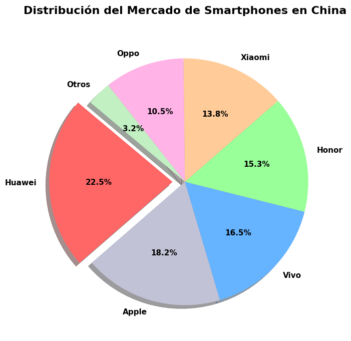

```python
# Datos simulados de cuota de mercado para China (porcentajes)
marcas = ['Huawei', 'Apple', 'Vivo', 'Honor', 'Xiaomi', 'Oppo', 'Otros']
cuota_mercado = [22.5, 18.2, 16.5, 15.3, 13.8, 10.5, 3.2]

# Colores y separacion (explode) para enfatizar la primera marca
colores = ['#ff6666', '#c2c2d6', '#66b3ff', '#99ff99', '#ffcc99', '#ffb3e6', '#c2f0c2']
separacion = (0.1, 0, 0, 0, 0, 0, 0)

# Crear el grafico
plt.figure(figsize=(8, 8))
plt.pie(cuota_mercado, explode=separacion, labels=marcas, colors=colores,
        autopct='%1.1f%%', shadow=True, startangle=140,
        textprops={'fontsize': 11, 'fontweight': 'bold'})

# Agregar titulo
plt.title('Distribución del Mercado de Smartphones en China', fontsize=16, fontweight='bold', pad=20)

# Exportar y mostrar (con manejo de errores si no existe la carpeta 'imgs')
try:
    plt.savefig('imgs/distribucion_mercado_pie.png', dpi=300, bbox_inches='tight')
except FileNotFoundError:
    print("Aviso: Carpeta 'imgs' no encontrada. Guardando en el directorio actual.")
    plt.savefig('distribucion_mercado_pie.png', dpi=300, bbox_inches='tight')

plt.show()
```

### 2. Grafico de Barras: Consumo de Agua vs. Refrescos en America Latina

Esta visualización compara el consumo anual estimado per cápita de agua embotellada y refrescos (sodas) en cuatro de los principales países de América Latina. Un gráfico de barras agrupadas es ideal aquí porque nos permite comparar dos categorías diferentes Agua y Refresco lado a lado dentro de grupos distintos Países.

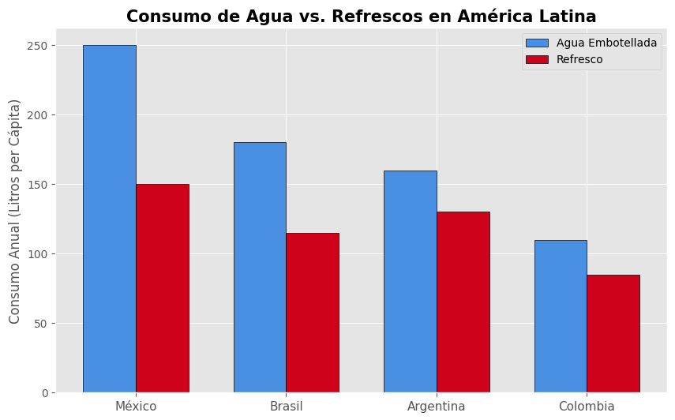

```python
# Datos simulados de consumo (Litros per capita anualmente)
paises = ['México', 'Brasil', 'Argentina', 'Colombia']
consumo_agua = np.array([250, 180, 160, 110])
consumo_refresco = np.array([150, 115, 130, 85])

x = np.arange(len(paises))  # Posiciones de las etiquetas
ancho = 0.35  # Ancho de las barras

# Crear el grafico
fig, ax = plt.subplots(figsize=(10, 6))
barras1 = ax.bar(x - ancho/2, consumo_agua, ancho, label='Agua Embotellada', color='#4a90e2', edgecolor='black')
barras2 = ax.bar(x + ancho/2, consumo_refresco, ancho, label='Refresco', color='#d0021b', edgecolor='black')

# Agregar etiquetas, título y personalizar el eje X
ax.set_ylabel('Consumo Anual (Litros per Cápita)', fontsize=12)
ax.set_title('Consumo de Agua vs. Refrescos en América Latina', fontsize=15, fontweight='bold')
ax.set_xticks(x)
ax.set_xticklabels(paises, fontsize=11)
ax.legend(loc='upper right', framealpha=1)

# Exportar y mostrar
try:
    plt.savefig('imgs/consumo_bebidas_barras.png', dpi=300, bbox_inches='tight')
except FileNotFoundError:
    print("Aviso: Carpeta 'imgs' no encontrada. Guardando en el directorio actual.")
    plt.savefig('consumo_bebidas_barras.png', dpi=300, bbox_inches='tight')

plt.show()
```

### 3. Grafico de Lineas: Videos Acumulados en YouTube a lo Largo del Tiempo

Este gráfico rastrea una simulación del crecimiento exponencial del número total de videos subidos a YouTube desde su creación. Un gráfico de líneas es la opción estándar y más efectiva para datos de series temporales, ya que los puntos conectados ilustran claramente la trayectoria, la velocidad de crecimiento y la tendencia general.

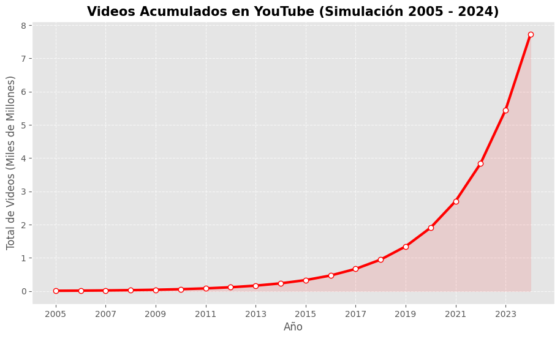

```python
# Generar datos simulados de series temporales exponenciales
anios = np.arange(2005, 2025)
# Simulando un crecimiento exponencial rápido en miles de millones
videos_billones = 0.01 * np.exp(0.35 * (anios - 2005))

# Crear el gráfico
plt.figure(figsize=(11, 6))
plt.plot(anios, videos_billones, color='#FF0000', linewidth=3, marker='o', markersize=6, markerfacecolor='white')

# Rellenar el área bajo la curva por estética
plt.fill_between(anios, videos_billones, color='#FF0000', alpha=0.1)

# Añadir etiquetas y título
plt.title('Videos Acumulados en YouTube (Simulación 2005 - 2024)', fontsize=15, fontweight='bold')
plt.xlabel('Año', fontsize=12)
plt.ylabel('Total de Videos (Miles de Millones)', fontsize=12)

# Asegurar que el eje X muestre solo años enteros
plt.xticks(np.arange(2005, 2025, 2))
plt.grid(True, linestyle='--', alpha=0.7)

# Exportar y mostrar
try:
    plt.savefig('imgs/crecimiento_youtube_lineas.png', dpi=300, bbox_inches='tight')
except FileNotFoundError:
    print("Aviso: Carpeta 'imgs' no encontrada. Guardando en el directorio actual.")
    plt.savefig('crecimiento_youtube_lineas.png', dpi=300, bbox_inches='tight')

plt.show()
```

### 4. Grafico de Dispersion: Rendimiento de Chips (Ley de Moore)

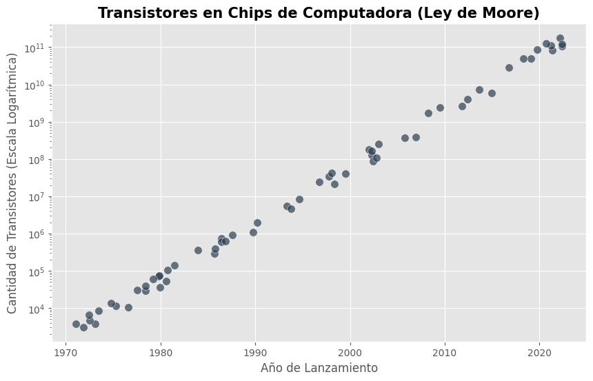

```python
# Generar datos simulados que representan la Ley de Moore
np.random.seed(42)
anios_lanzamiento = np.random.uniform(1970, 2024, 60)
# Ecuacion base: el recuento se duplica aprox. cada 2 años
recuento_transistores = 2000 * (2 ** ((anios_lanzamiento - 1970) / 2))
# Añadir ruido aleatorio para simular la varianza del mundo real
recuento_transistores *= np.random.uniform(0.5, 1.5, 60)

# Crear el gráfico
plt.figure(figsize=(10, 6))
plt.scatter(anios_lanzamiento, recuento_transistores, color='#2c3e50', alpha=0.7, edgecolors='white', s=70)

# Agregar etiquetas, titulo y establecer el eje Y a escala logarítmica
plt.yscale('log')
plt.title("Transistores en Chips de Computadora (Ley de Moore)", fontsize=15, fontweight='bold')
plt.xlabel('Año de Lanzamiento', fontsize=12)
plt.ylabel('Cantidad de Transistores (Escala Logarítmica)', fontsize=12)

# Exportar y mostrar
try:
    plt.savefig('imgs/rendimiento_chips_dispersion.png', dpi=300, bbox_inches='tight')
except FileNotFoundError:
    print("Aviso: Carpeta 'imgs' no encontrada. Guardando en el directorio actual.")
    plt.savefig('rendimiento_chips_dispersion.png', dpi=300, bbox_inches='tight')

plt.show()
```